# Small Test Exact Solution Vectorized Bisection

This is the example vignette for function: [snw_vfi_main_bisec_vec](https://github.com/FanWangEcon/PrjOptiSNW/tree/master/PrjOptiSNW/svalpol/snw_vfi_main_bisec_vec.m) from the [PrjOptiSNW Package](https://fanwangecon.github.io/PrjOptiSNW/). This function solves for policy function with vectorized bisection. Small Solution Analysis. Small Solution Analysis, husband 5 shocks, wife 1 shocks.

## Test SNW_VFI_MAIN Defaults Small

Call the function with defaults parameters.

```matlab
mp_param = snw_mp_param('default_small');
[V_VFI,ap_VFI,cons_VFI,mp_valpol_more] = snw_vfi_main_bisec_vec(mp_param);
```

SNW_VFI_MAIN_BISEC_VEC: Finished Age Group:18 of 17, time-this-age:0.06059 SNW_VFI_MAIN_BISEC_VEC: Finished Age Group:17 of 17, time-this-age:0.052828 SNW_VFI_MAIN_BISEC_VEC: Finished Age Group:16 of 17, time-this-age:0.032745 SNW_VFI_MAIN_BISEC_VEC: Finished Age Group:15 of 17, time-this-age:0.029085 SNW_VFI_MAIN_BISEC_VEC: Finished Age Group:14 of 17, time-this-age:0.035583 SNW_VFI_MAIN_BISEC_VEC: Finished Age Group:13 of 17, time-this-age:0.034991 SNW_VFI_MAIN_BISEC_VEC: Finished Age Group:12 of 17, time-this-age:0.033648 SNW_VFI_MAIN_BISEC_VEC: Finished Age Group:11 of 17, time-this-age:0.032963 SNW_VFI_MAIN_BISEC_VEC: Finished Age Group:10 of 17, time-this-age:0.033174 SNW_VFI_MAIN_BISEC_VEC: Finished Age Group:9 of 17, time-this-age:0.036843 SNW_VFI_MAIN_BISEC_VEC: Finished Age Group:8 of 17, time-this-age:0.04052 SNW_VFI_MAIN_BISEC_VEC: Finished Age Group:7 of 17, time-this-age:0.028633 SNW_VFI_MAIN_BISEC_VEC: Finished Age Group:6 of 17, time-this-age:0.035108 SNW_VFI_MAIN_BISEC_VEC: Finished Age Group:5 of 17, time-this-age:0.033838 SNW_VFI_MAIN_BISEC_VEC: Finished Age Group:4 of 17, time-this-age:0.033585 SNW_VFI_MAIN_BISEC_VEC: Finished Age Group:3 of 17, time-this-age:0.03214 SNW_VFI_MAIN_BISEC_VEC: Finished Age Group:2 of 17, time-this-age:0.028888 SNW_VFI_MAIN_BISEC_VEC: Finished Age Group:1 of 17, time-this-age:0.031611 Completed SNW_VFI_MAIN_BISEC_VEC;SNW_MP_PARAM=default_small;SNW_MP_CONTROL=default_base;time=0.72345

## Small Param Results Define Frames

Define the matrix dimensions names and dimension vector values. Policy and Value Functions share the same ND dimensional structure.

```matlab
% Grids:
age_grid = [19, 22:5:97, 100];
agrid = mp_param('agrid')';
eta_H_grid = mp_param('eta_H_grid')';
eta_S_grid = mp_param('eta_S_grid')';
ar_st_eta_HS_grid = string(cellstr([num2str(eta_H_grid', 'hz=%3.2f;'), num2str(eta_S_grid', 'wz=%3.2f')]));
edu_grid = [0,1];
marry_grid = [0,1];
kids_grid = (1:1:mp_param('n_kidsgrid'))';
% NaN(n_jgrid,n_agrid,n_etagrid,n_educgrid,n_marriedgrid,n_kidsgrid);
cl_mp_datasetdesc = {};
cl_mp_datasetdesc{1} = containers.Map({'name', 'labval'}, {'age', age_grid});
cl_mp_datasetdesc{2} = containers.Map({'name', 'labval'}, {'savings', agrid});
cl_mp_datasetdesc{3} = containers.Map({'name', 'labval'}, {'Hshock', eta_H_grid});
cl_mp_datasetdesc{4} = containers.Map({'name', 'labval'}, {'edu', edu_grid});
cl_mp_datasetdesc{5} = containers.Map({'name', 'labval'}, {'marry', marry_grid});
cl_mp_datasetdesc{6} = containers.Map({'name', 'labval'}, {'kids', kids_grid});
```

## Analyze Savings and Shocks

First, analyze Savings Levels and Shocks, Aggregate Over All Others, and do various other calculations.

```matlab
% Generate some Data
mp_support_graph = containers.Map('KeyType', 'char', 'ValueType', 'any');
mp_support_graph('cl_st_xtitle') = {'Savings States, a'};
mp_support_graph('st_legend_loc') = 'best';
mp_support_graph('bl_graph_logy') = true; % do not log
```

MEAN(VAL(A,Z)), MEAN(AP(A,Z)), MEAN(C(A,Z))

Tabulate value and policies along savings and shocks:

```matlab
% Set
% NaN(n_jgrid,n_agrid,n_etagrid,n_educgrid,n_marriedgrid,n_kidsgrid);
ar_permute = [1,4,5,6,3,2];
% Value Function
tb_az_v = ff_summ_nd_array("MEAN(VAL(A,Z))", V_VFI, true, ["mean"], 4, 1, cl_mp_datasetdesc, ar_permute);
```

xxx MEAN(VAL(A,Z)) xxxxxxxxxxxxxxxxxxxxxxxxxxx **group** **savings** **mean_Hshock__1_8395** **mean_Hshock__0_91976** **mean_Hshock_0** **mean_Hshock_0_91976** **mean_Hshock_1_8395** **_____** **_________** **___________________** **____________________** **_____________** **___________________** **__________________** 1 0 -21.426 -13.175 -8.362 -5.4972 -3.9407 2 0.0097656 -20.989 -13.027 -8.2755 -5.4264 -3.874 3 0.078125 -18.901 -12.204 -7.8053 -5.0563 -3.5316 4 0.26367 -15.612 -10.744 -7.0124 -4.4893 -3.033 5 0.625 -12.124 -8.9835 -6.0664 -3.8998 -2.5588 6 1.2207 -9.0979 -7.2177 -5.0967 -3.3546 -2.1657 7 2.1094 -6.7401 -5.6532 -4.2107 -2.8614 -1.8516 8 3.3496 -4.9967 -4.3739 -3.4359 -2.4175 -1.5968 9 5 -3.7353 -3.3758 -2.7788 -2.0342 -1.3834 10 7.1191 -2.8279 -2.617 -2.2393 -1.7115 -1.1997 11 9.7656 -2.172 -2.0455 -1.8057 -1.4379 -1.0388 12 12.998 -1.693 -1.6153 -1.4614 -1.2066 -0.89932 13 16.875 -1.3389 -1.2899 -1.1896 -1.0131 -0.77961 14 21.455 -1.0737 -1.042 -0.97552 -0.85247 -0.67683 15 26.797 -0.872 -0.85104 -0.80614 -0.71965 -0.58803 16 32.959 -0.71656 -0.70236 -0.67148 -0.61005 -0.51138 17 40 -0.59521 -0.58538 -0.56375 -0.5196 -0.4454 18 47.979 -0.49932 -0.49238 -0.47697 -0.44484 -0.38876 19 56.953 -0.42266 -0.41768 -0.40651 -0.38285 -0.3402 20 66.982 -0.36074 -0.3571 -0.34889 -0.33125 -0.29857 21 78.125 -0.31022 -0.30751 -0.30139 -0.28809 -0.26288 22 90.439 -0.26861 -0.26658 -0.26196 -0.25181 -0.23222 23 103.98 -0.23407 -0.23252 -0.22899 -0.22118 -0.20583 24 118.82 -0.20516 -0.20397 -0.20125 -0.19517 -0.18307 25 135 -0.1808 -0.17987 -0.17775 -0.17298 -0.16337

```matlab
% Aprime Choice
tb_az_ap = ff_summ_nd_array("MEAN(AP(A,Z))", ap_VFI, true, ["mean"], 4, 1, cl_mp_datasetdesc, ar_permute);
```

xxx MEAN(AP(A,Z)) xxxxxxxxxxxxxxxxxxxxxxxxxxx **group** **savings** **mean_Hshock__1_8395** **mean_Hshock__0_91976** **mean_Hshock_0** **mean_Hshock_0_91976** **mean_Hshock_1_8395** **_____** **_________** **___________________** **____________________** **_____________** **___________________** **__________________** 1 0 3.2159e-05 0.0034995 0.049878 0.24382 0.89303 2 0.0097656 0.00055365 0.0052722 0.053281 0.24787 0.89865 3 0.078125 0.021863 0.029676 0.083029 0.2805 0.93962 4 0.26367 0.13323 0.14751 0.20012 0.38877 1.059 5 0.625 0.39134 0.41034 0.45315 0.64573 1.3086 6 1.2207 0.84131 0.86393 0.91226 1.0928 1.745 7 2.1094 1.5303 1.5542 1.6156 1.7559 2.3963 8 3.3496 2.4876 2.5118 2.573 2.6876 3.3398 9 5 3.7642 3.7887 3.8498 3.9922 4.592 10 7.1191 5.4275 5.4525 5.5145 5.6929 6.1933 11 9.7656 7.4794 7.5043 7.5679 7.7532 8.1877 12 12.998 9.9124 9.9329 9.9956 10.186 10.627 13 16.875 12.928 12.95 13.005 13.196 13.715 14 21.455 16.529 16.548 16.604 16.783 17.374 15 26.797 20.601 20.618 20.668 20.837 21.462 16 32.959 25.307 25.325 25.37 25.525 26.151 17 40 30.667 30.689 30.742 30.886 31.487 18 47.979 36.761 36.782 36.841 36.999 37.562 19 56.953 43.773 43.795 43.847 44.012 44.56 20 66.982 51.605 51.628 51.688 51.85 52.402 21 78.125 59.954 59.977 60.037 60.209 60.766 22 90.439 69.265 69.288 69.35 69.526 70.095 23 103.98 79.75 79.771 79.831 80.004 80.583 24 118.82 91.112 91.136 91.198 91.364 91.939 25 135 103.47 103.49 103.54 103.72 104.29

```matlab
% Consumption Choices
tb_az_c = ff_summ_nd_array("MEAN(C(A,Z))", cons_VFI, true, ["mean"], 4, 1, cl_mp_datasetdesc, ar_permute);
```

xxx MEAN(C(A,Z)) xxxxxxxxxxxxxxxxxxxxxxxxxxx **group** **savings** **mean_Hshock__1_8395** **mean_Hshock__0_91976** **mean_Hshock_0** **mean_Hshock_0_91976** **mean_Hshock_1_8395** **_____** **_________** **___________________** **____________________** **_____________** **___________________** **__________________** 1 0 0.30273 0.43104 0.68779 1.2165 2.3366 2 0.0097656 0.31374 0.44074 0.69581 1.2239 2.3424 3 0.078125 0.37308 0.49663 0.74605 1.271 2.3812 4 0.26367 0.48039 0.59659 0.846 1.3793 2.4781 5 0.625 0.64735 0.75745 1.0153 1.5439 2.6497 6 1.2207 0.89649 1.0013 1.2519 1.7913 2.9071 7 2.1094 1.2479 1.3498 1.5854 2.1634 3.2903 8 3.3496 1.7393 1.8394 2.0734 2.6754 3.7896 9 5 2.3872 2.4859 2.7182 3.2909 4.4564 10 7.1191 3.1917 3.289 3.5191 4.0542 5.3181 11 9.7656 4.2188 4.3155 4.543 5.07 6.3986 12 12.998 5.5439 5.6447 5.8722 6.3933 7.7142 13 16.875 7.0334 7.133 7.3676 7.8866 9.1285 14 21.455 8.754 8.8551 9.0887 9.6188 10.789 15 26.797 10.886 10.989 11.228 11.768 12.903 16 32.959 13.336 13.439 13.682 14.235 15.368 17 40 16.151 16.249 16.485 17.049 18.207 18 47.979 19.321 19.42 19.65 20.2 21.395 19 56.953 22.728 22.827 23.062 23.605 24.816 20 66.982 26.539 26.637 26.865 27.41 28.616 21 78.125 31.125 31.222 31.451 31.986 33.187 22 90.439 36.11 36.207 36.433 36.965 38.154 23 103.98 41.348 41.447 41.676 42.21 43.389 24 118.82 47.206 47.302 47.528 48.07 49.252 25 135 53.636 53.735 53.966 54.501 55.689

Graph Mean Values:

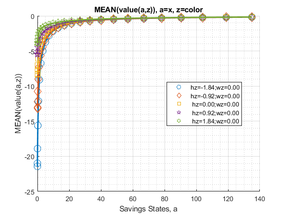

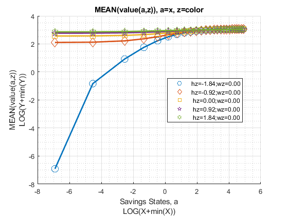

```matlab
mp_support_graph('cl_st_graph_title') = {'MEAN(value(a,z)), a=x, z=color'};
mp_support_graph('cl_st_ytitle') = {'MEAN(value(a,z))'};
ff_graph_grid((tb_az_v{1:end, 3:end})', ar_st_eta_HS_grid, agrid, mp_support_graph);
```

Graph Mean Savings Choices:

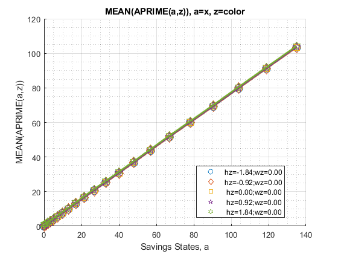

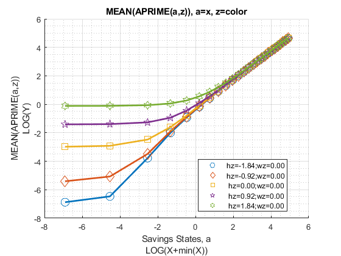

```matlab
mp_support_graph('cl_st_graph_title') = {'MEAN(APRIME(a,z)), a=x, z=color'};
mp_support_graph('cl_st_ytitle') = {'MEAN(APRIME(a,z))'};
ff_graph_grid((tb_az_ap{1:end, 3:end})', ar_st_eta_HS_grid, agrid, mp_support_graph);
```

Graph Mean Consumption:

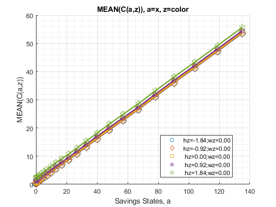

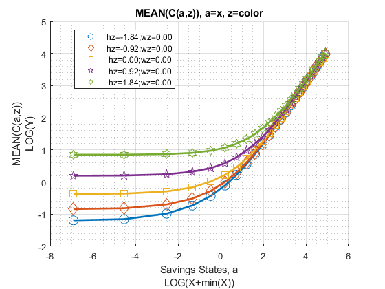

```matlab
mp_support_graph('cl_st_graph_title') = {'MEAN(C(a,z)), a=x, z=color'};
mp_support_graph('cl_st_ytitle') = {'MEAN(C(a,z))'};
ff_graph_grid((tb_az_c{1:end, 3:end})', ar_st_eta_HS_grid, agrid, mp_support_graph);
```

## Analyze Kids and Marriage and Age

Aggregating over education, savings, and shocks, what are the differential effects of Marriage and Age.

```matlab
% Generate some Data
mp_support_graph = containers.Map('KeyType', 'char', 'ValueType', 'any');
ar_row_grid = ["k0M0", "K1M0", "K2M0", "k0M1", "K1M1", "K2M1"];
mp_support_graph('cl_st_xtitle') = {'Age'};
mp_support_graph('st_legend_loc') = 'best';
mp_support_graph('bl_graph_logy') = true; % do not log
mp_support_graph('st_rounding') = '6.2f'; % format shock legend
mp_support_graph('cl_scatter_shapes') = { 'o', 'd' ,'s', 'o', 'd', 's'};
mp_support_graph('cl_colors') = {'red', 'red', 'red', 'blue', 'blue', 'blue'};
```

MEAN(VAL(KM,J)), MEAN(AP(KM,J)), MEAN(C(KM,J))

Tabulate value and policies:

```matlab
% Set
% NaN(n_jgrid,n_agrid,n_etagrid,n_educgrid,n_marriedgrid,n_kidsgrid);
ar_permute = [2,3,4,1,6,5];
% Value Function
tb_az_v = ff_summ_nd_array("MEAN(VAL(KM,J))", V_VFI, true, ["mean"], 3, 1, cl_mp_datasetdesc, ar_permute);
```

xxx MEAN(VAL(KM,J)) xxxxxxxxxxxxxxxxxxxxxxxxxxx **group** **kids** **marry** **mean_age_19** **mean_age_22** **mean_age_27** **mean_age_32** **mean_age_37** **mean_age_42** **mean_age_47** **mean_age_52** **mean_age_57** **mean_age_62** **mean_age_67** **mean_age_72** **mean_age_77** **mean_age_82** **mean_age_87** **mean_age_92** **mean_age_97** **mean_age_100** **_____** **____** **_____** **___________** **___________** **___________** **___________** **___________** **___________** **___________** **___________** **___________** **___________** **___________** **___________** **___________** **___________** **___________** **___________** **___________** **____________** 1 1 0 -4.7384 -4.2839 -3.9125 -3.6403 -3.4202 -3.2286 -3.0466 -2.8601 -2.6595 -2.4491 -2.2399 -2.0731 -2.3629 -1.8637 -1.4355 -1.116 -0.89281 -0.68658 2 2 0 -6.2307 -5.5732 -5.014 -4.5943 -4.2483 -3.9542 -3.6887 -3.434 -3.1782 -2.9257 -2.6801 -2.4926 -2.8794 -2.3137 -1.8328 -1.4683 -1.2096 -0.97097 3 3 0 -6.9818 -6.3368 -5.7685 -5.3334 -4.9708 -4.6532 -4.3595 -4.0736 -3.7846 -3.4985 -3.2208 -3.0125 -3.5228 -2.8558 -2.2747 -1.8248 -1.5002 -1.1892 4 1 1 -4.1822 -3.7934 -3.4691 -3.2086 -2.984 -2.7815 -2.5887 -2.3963 -2.1988 -2.0023 -1.8175 -1.6729 -1.7337 -1.3601 -1.0432 -0.80128 -0.63711 -0.48578 5 2 1 -5.157 -4.667 -4.2348 -3.8784 -3.5654 -3.2867 -3.0293 -2.7824 -2.5391 -2.3051 -2.0863 -1.9132 -1.9616 -1.5551 -1.2079 -0.94165 -0.76108 -0.59364 6 3 1 -5.5929 -5.1267 -4.7056 -4.352 -4.0378 -3.7489 -3.4736 -3.2028 -2.9306 -2.6639 -2.4094 -2.1983 -2.2235 -1.7704 -1.3796 -1.0769 -0.86971 -0.67418

```matlab
% Aprime Choice
tb_az_ap = ff_summ_nd_array("MEAN(AP(KM,J))", ap_VFI, true, ["mean"], 3, 1, cl_mp_datasetdesc, ar_permute);
```

xxx MEAN(AP(KM,J)) xxxxxxxxxxxxxxxxxxxxxxxxxxx **group** **kids** **marry** **mean_age_19** **mean_age_22** **mean_age_27** **mean_age_32** **mean_age_37** **mean_age_42** **mean_age_47** **mean_age_52** **mean_age_57** **mean_age_62** **mean_age_67** **mean_age_72** **mean_age_77** **mean_age_82** **mean_age_87** **mean_age_92** **mean_age_97** **mean_age_100** **_____** **____** **_____** **___________** **___________** **___________** **___________** **___________** **___________** **___________** **___________** **___________** **___________** **___________** **___________** **___________** **___________** **___________** **___________** **___________** **____________** 1 1 0 34.931 34.726 34.665 34.554 34.362 34.077 33.682 33.147 32.422 31.5 30.819 29.713 26.817 24.458 21.039 16.761 11.058 0 2 2 0 34.603 34.334 34.198 33.995 33.692 33.286 32.762 32.089 31.289 30.736 29.885 28.361 25.892 23.172 19.841 15.524 10.196 0 3 3 0 34.187 33.968 33.877 33.705 33.427 33.033 32.51 31.83 31.11 30.61 29.726 28.203 25.828 23.157 19.895 15.696 10.38 0 4 1 1 34.821 34.617 34.566 34.458 34.268 33.984 33.592 33.061 32.337 31.426 30.766 29.672 26.686 24.311 20.849 16.614 10.957 0 5 2 1 34.67 34.45 34.364 34.205 33.951 33.592 33.119 32.502 31.689 30.947 30.272 28.936 26.238 23.551 20.155 16.013 10.39 0 6 3 1 34.303 34.118 34.065 33.937 33.705 33.363 32.896 32.277 31.468 30.828 30.119 28.736 26.155 23.47 20.114 16.016 10.488 0

```matlab
% Consumption Choices
tb_az_c = ff_summ_nd_array("MEAN(C(KM,J))", cons_VFI, true, ["mean"], 3, 1, cl_mp_datasetdesc, ar_permute);
```

xxx MEAN(C(KM,J)) xxxxxxxxxxxxxxxxxxxxxxxxxxx **group** **kids** **marry** **mean_age_19** **mean_age_22** **mean_age_27** **mean_age_32** **mean_age_37** **mean_age_42** **mean_age_47** **mean_age_52** **mean_age_57** **mean_age_62** **mean_age_67** **mean_age_72** **mean_age_77** **mean_age_82** **mean_age_87** **mean_age_92** **mean_age_97** **mean_age_100** **_____** **____** **_____** **___________** **___________** **___________** **___________** **___________** **___________** **___________** **___________** **___________** **___________** **___________** **___________** **___________** **___________** **___________** **___________** **___________** **____________** 1 1 0 6.8531 7.1729 7.4988 7.8167 8.1435 8.4993 8.9181 9.4437 10.134 10.995 11.582 12.551 14.27 16.629 20.048 24.326 30.029 41.087 2 2 0 7.182 7.5653 7.9659 8.3756 8.813 9.2907 9.8382 10.502 11.267 11.759 12.516 13.903 15.195 17.915 21.247 25.563 30.891 41.087 3 3 0 7.5973 7.931 8.2872 8.6657 9.0783 9.5438 10.091 10.761 11.445 11.885 12.675 14.061 15.259 17.93 21.192 25.392 30.707 41.087 4 1 1 7.1848 7.5242 7.8662 8.2047 8.552 8.9277 9.3635 9.904 10.61 11.476 12.055 13.024 14.702 17.087 20.557 24.8 30.464 41.428 5 2 1 7.3021 7.6535 8.0269 8.412 8.8205 9.2678 9.7814 10.405 11.198 11.892 12.485 13.693 15.151 17.848 21.253 25.403 31.033 41.43 6 3 1 7.6455 7.9599 8.297 8.6497 9.0324 9.462 9.9672 10.591 11.378 11.968 12.594 13.847 15.246 17.941 21.307 25.412 30.948 41.443

Graph Mean Values:

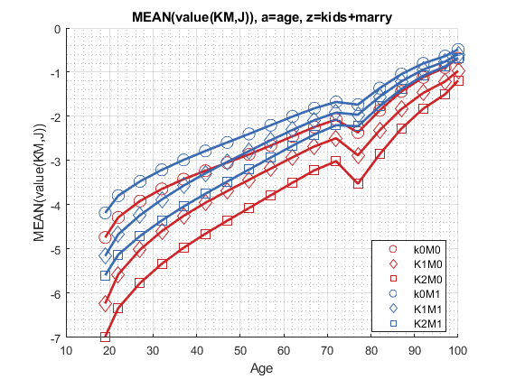

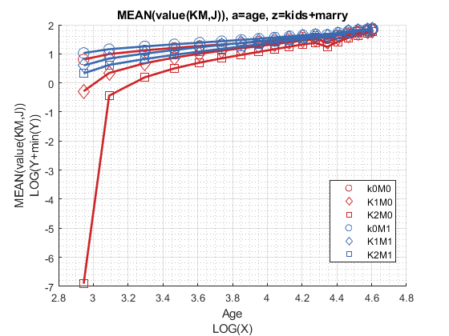

```matlab
mp_support_graph('cl_st_graph_title') = {'MEAN(value(KM,J)), a=age, z=kids+marry'};
mp_support_graph('cl_st_ytitle') = {'MEAN(value(KM,J))'};
ff_graph_grid((tb_az_v{1:end, 4:end}), ar_row_grid, age_grid, mp_support_graph);
```

Graph Mean Savings Choices:

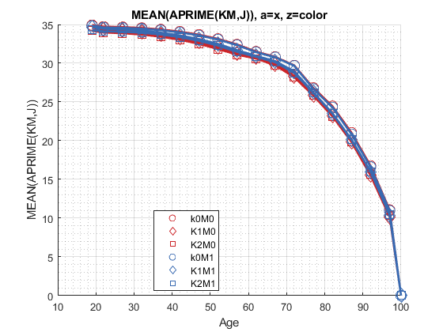

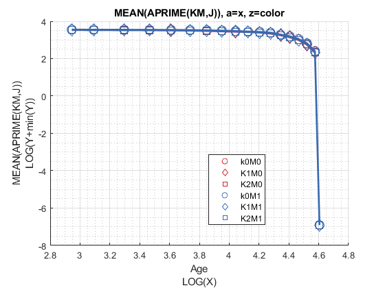

```matlab
mp_support_graph('cl_st_graph_title') = {'MEAN(APRIME(KM,J)), a=x, z=color'};
mp_support_graph('cl_st_ytitle') = {'MEAN(APRIME(KM,J))'};
ff_graph_grid((tb_az_ap{1:end, 4:end}), ar_row_grid, age_grid, mp_support_graph);
```

Graph Mean Consumption:

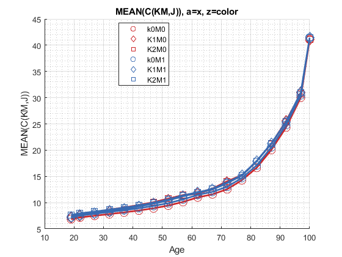

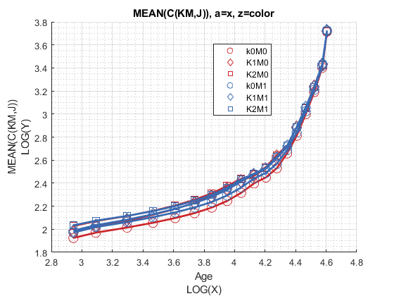

```matlab
mp_support_graph('cl_st_graph_title') = {'MEAN(C(KM,J)), a=x, z=color'};
mp_support_graph('cl_st_ytitle') = {'MEAN(C(KM,J))'};
ff_graph_grid((tb_az_c{1:end, 4:end}), ar_row_grid, age_grid, mp_support_graph);
```

## Analyze Education and Marriage and Age

```matlab
% Generate some Data
mp_support_graph = containers.Map('KeyType', 'char', 'ValueType', 'any');
ar_row_grid = ["E0M0", "E1M0", "E0M1", "E1M1"];
mp_support_graph('cl_st_xtitle') = {'Age'};
mp_support_graph('st_legend_loc') = 'best';
mp_support_graph('bl_graph_logy') = true; % do not log
mp_support_graph('st_rounding') = '6.2f'; % format shock legend
mp_support_graph('cl_scatter_shapes') = {'*', 'p', '*','p' };
mp_support_graph('cl_colors') = {'red', 'red', 'blue', 'blue'};
```

MEAN(VAL(EKM,J)), MEAN(AP(EKM,J)), MEAN(C(EKM,J))

Tabulate value and policies:

```matlab
% Set
% NaN(n_jgrid,n_agrid,n_etagrid,n_educgrid,n_marriedgrid,n_kidsgrid);
ar_permute = [2,3,6,1,4,5];
% Value Function
tb_az_v = ff_summ_nd_array("MEAN(VAL(EKM,J))", V_VFI, true, ["mean"], 3, 1, cl_mp_datasetdesc, ar_permute);
```

xxx MEAN(VAL(EKM,J)) xxxxxxxxxxxxxxxxxxxxxxxxxxx **group** **edu** **marry** **mean_age_19** **mean_age_22** **mean_age_27** **mean_age_32** **mean_age_37** **mean_age_42** **mean_age_47** **mean_age_52** **mean_age_57** **mean_age_62** **mean_age_67** **mean_age_72** **mean_age_77** **mean_age_82** **mean_age_87** **mean_age_92** **mean_age_97** **mean_age_100** **_____** **___** **_____** **___________** **___________** **___________** **___________** **___________** **___________** **___________** **___________** **___________** **___________** **___________** **___________** **___________** **___________** **___________** **___________** **___________** **____________** 1 0 0 -6.4015 -5.8666 -5.3879 -4.9966 -4.6557 -4.3525 -4.0711 -3.7972 -3.5191 -3.2399 -2.9631 -2.7398 -3.0999 -2.4877 -1.9609 -1.561 -1.2765 -1.0093 2 1 0 -5.5658 -4.9294 -4.4088 -4.0487 -3.7705 -3.5382 -3.3254 -3.1146 -2.8958 -2.6757 -2.4641 -2.3123 -2.7435 -2.201 -1.7345 -1.3784 -1.1253 -0.88856 3 0 1 -5.35 -4.913 -4.5196 -4.1777 -3.867 -3.5814 -3.3116 -3.049 -2.7867 -2.5306 -2.2873 -2.0881 -2.1106 -1.6708 -1.2955 -1.0066 -0.80985 -0.62643 4 1 1 -4.6046 -4.1451 -3.7534 -3.4483 -3.1912 -2.9633 -2.7494 -2.5387 -2.3256 -2.1169 -1.9214 -1.7682 -1.8352 -1.4529 -1.1251 -0.87332 -0.70209 -0.54263

```matlab
% Aprime Choice
tb_az_ap = ff_summ_nd_array("MEAN(AP(EKM,J))", ap_VFI, true, ["mean"], 3, 1, cl_mp_datasetdesc, ar_permute);
```

xxx MEAN(AP(EKM,J)) xxxxxxxxxxxxxxxxxxxxxxxxxxx **group** **edu** **marry** **mean_age_19** **mean_age_22** **mean_age_27** **mean_age_32** **mean_age_37** **mean_age_42** **mean_age_47** **mean_age_52** **mean_age_57** **mean_age_62** **mean_age_67** **mean_age_72** **mean_age_77** **mean_age_82** **mean_age_87** **mean_age_92** **mean_age_97** **mean_age_100** **_____** **___** **_____** **___________** **___________** **___________** **___________** **___________** **___________** **___________** **___________** **___________** **___________** **___________** **___________** **___________** **___________** **___________** **___________** **___________** **____________** 1 0 0 34.682 34.444 34.272 34.048 33.753 33.374 32.888 32.256 31.512 30.851 30.02 28.595 26.17 23.589 20.254 15.987 10.542 0 2 1 0 34.465 34.241 34.222 34.121 33.901 33.556 33.081 32.455 31.703 31.046 30.267 28.923 26.188 23.603 20.262 16 10.548 0 3 0 1 34.725 34.514 34.372 34.177 33.914 33.569 33.12 32.528 31.74 30.976 30.277 28.965 26.367 23.79 20.393 16.226 10.623 0 4 1 1 34.47 34.277 34.291 34.223 34.035 33.724 33.285 32.699 31.923 31.158 30.495 29.265 26.352 23.764 20.352 16.203 10.601 0

```matlab
% Consumption Choices
tb_az_c = ff_summ_nd_array("MEAN(C(EKM,J))", cons_VFI, true, ["mean"], 3, 1, cl_mp_datasetdesc, ar_permute);
```

xxx MEAN(C(EKM,J)) xxxxxxxxxxxxxxxxxxxxxxxxxxx **group** **edu** **marry** **mean_age_19** **mean_age_22** **mean_age_27** **mean_age_32** **mean_age_37** **mean_age_42** **mean_age_47** **mean_age_52** **mean_age_57** **mean_age_62** **mean_age_67** **mean_age_72** **mean_age_77** **mean_age_82** **mean_age_87** **mean_age_92** **mean_age_97** **mean_age_100** **_____** **___** **_____** **___________** **___________** **___________** **___________** **___________** **___________** **___________** **___________** **___________** **___________** **___________** **___________** **___________** **___________** **___________** **___________** **___________** **____________** 1 0 0 7.1022 7.4087 7.7357 8.0845 8.4713 8.9105 9.427 10.062 10.782 11.389 12.136 13.445 14.9 17.48 20.815 25.082 30.528 41.07 2 1 0 7.3195 7.7041 8.0988 8.4875 8.8852 9.312 9.8044 10.409 11.116 11.703 12.379 13.565 14.917 17.502 20.843 25.105 30.557 41.105 3 0 1 7.2307 7.5253 7.8393 8.1757 8.5471 8.9685 9.4633 10.073 10.85 11.572 12.198 13.402 14.973 17.559 20.964 25.138 30.748 41.376 4 1 1 7.5242 7.8997 8.2875 8.6685 9.0562 9.4697 9.9448 10.527 11.274 11.985 12.558 13.641 15.093 17.692 21.114 25.272 30.882 41.491

Graph Mean Values:

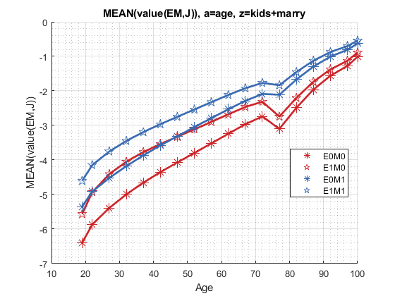

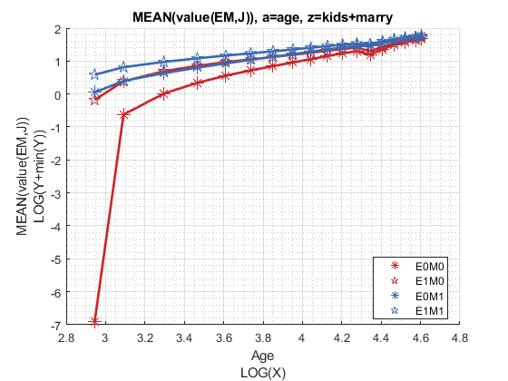

```matlab
mp_support_graph('cl_st_graph_title') = {'MEAN(value(EM,J)), a=age, z=kids+marry'};
mp_support_graph('cl_st_ytitle') = {'MEAN(value(EM,J))'};
ff_graph_grid((tb_az_v{1:end, 4:end}), ar_row_grid, age_grid, mp_support_graph);
```

Graph Mean Savings Choices:

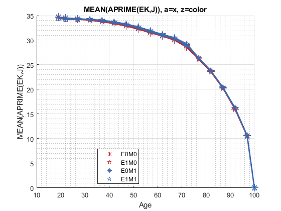

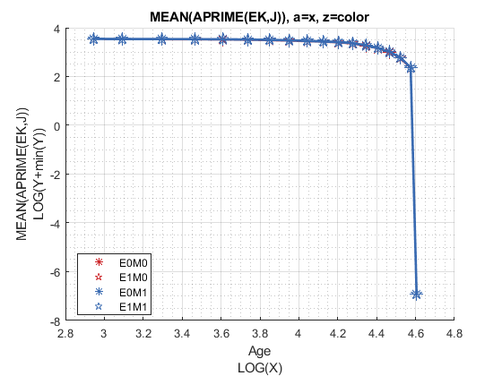

```matlab
mp_support_graph('cl_st_graph_title') = {'MEAN(APRIME(EK,J)), a=x, z=color'};
mp_support_graph('cl_st_ytitle') = {'MEAN(APRIME(EK,J))'};
ff_graph_grid((tb_az_ap{1:end, 4:end}), ar_row_grid, age_grid, mp_support_graph);
```

Graph Mean Consumption:

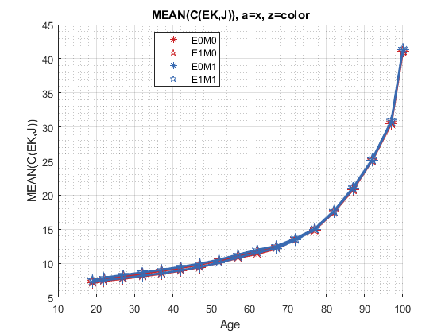

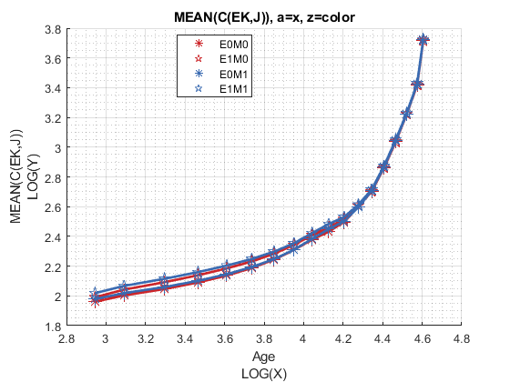

```matlab
mp_support_graph('cl_st_graph_title') = {'MEAN(C(EK,J)), a=x, z=color'};
mp_support_graph('cl_st_ytitle') = {'MEAN(C(EK,J))'};
ff_graph_grid((tb_az_c{1:end, 4:end}), ar_row_grid, age_grid, mp_support_graph);
```